# HEB_data_analysis

Schneider, Arnon, and Qi

8/28/2019

### Multi-level modeling in the English group based on the trial-by-trial data: fixed effects of task order (linguistic first or second), trial order (target or foil first), task (linguistic or non-linguistic), and trial (order of the test trials 1-25). Including task into random slope results in a non-converging model.

- no effect of task order
- significant effect of task
- significant effect of trial order (target first was more accurate)
- minimal effect of trial presentation order (later trials don’t appear to be more accurate than earlier trials)

```r
eng.lmer <- glmer(trial_accuracy ~ 1 + task_order + task + trial_order + trial + gender + (1|subject), family = binomial, control=glmerControl(optimizer="bobyqa", optCtrl=list(maxfun=2e5)), data = eng_trial)
summary(eng.lmer)
```

```
## Generalized linear mixed model fit by maximum likelihood (Laplace
##   Approximation) [glmerMod]
##  Family: binomial  ( logit )
## Formula: trial_accuracy ~ 1 + task_order + task + trial_order + trial +
##     gender + (1 | subject)
##    Data: eng_trial
## Control:
## glmerControl(optimizer = "bobyqa", optCtrl = list(maxfun = 2e+05))
##
##      AIC      BIC   logLik deviance df.resid
##   3556.1   3732.5  -1748.0   3496.1     2620
##
## Scaled residuals:
##     Min      1Q  Median      3Q     Max
## -2.1827 -1.0601  0.6518  0.8258  1.4616
##
## Random effects:
##  Groups  Name        Variance Std.Dev.
##  subject (Intercept) 0.06355  0.2521
## Number of obs: 2650, groups:  subject, 53
##
## Fixed effects:
##                  Estimate Std. Error z value Pr(>|z|)
## (Intercept)      0.313994   0.090439   3.472 0.000517 ***
## task_order1     -0.128710   0.110849  -1.161 0.245587
## task1           -0.231935   0.080947  -2.865 0.004167 **
## trial_orderword  0.515466   0.081447   6.329 2.47e-10 ***
## trial1          -0.394798   0.237921  -1.659 0.097042 .
## trial2           0.151784   0.230473   0.659 0.510168
## trial3           0.012124   0.232960   0.052 0.958496
## trial4          -0.141946   0.233987  -0.607 0.544090
## trial5          -0.180940   0.232504  -0.778 0.436436
## trial6           0.093244   0.229003   0.407 0.683879
## trial7          -0.033110   0.230306  -0.144 0.885687
## trial8          -0.057726   0.230636  -0.250 0.802364
## trial9           0.103915   0.229201   0.453 0.650277
## trial10          0.274485   0.230089   1.193 0.232889
## trial11          0.195935   0.232592   0.842 0.399566
## trial12         -0.363215   0.238766  -1.521 0.128205
## trial13         -0.246469   0.233018  -1.058 0.290181
## trial14          0.006433   0.230092   0.028 0.977695
## trial15         -0.155401   0.230541  -0.674 0.500267
## trial16          0.418849   0.229076   1.828 0.067486 .
## trial17          0.349359   0.230497   1.516 0.129601
## trial18          0.357839   0.235080   1.522 0.127959
## trial19         -0.242696   0.244818  -0.991 0.321523
## trial20         -0.320322   0.242078  -1.323 0.185762
## trial21          0.169540   0.235419   0.720 0.471423
## trial22         -0.556969   0.245353  -2.270 0.023203 *
## trial23          0.398520   0.244016   1.633 0.102433
## trial24         -0.302680   0.286389  -1.057 0.290564
## gendermale      -0.140225   0.112265  -1.249 0.211643
## ---
## Signif. codes:  0 '***' 0.001 '**' 0.01 '*' 0.05 '.' 0.1 ' ' 1
```

```
##
## Correlation matrix not shown by default, as p = 29 > 12.
## Use print(x, correlation=TRUE)  or
##   vcov(x)     if you need it
```

```r
eng.lmer <- glmer(trial_accuracy ~ 1 + task_order + task + (1|subject), family = binomial, control=glmerControl(optimizer="bobyqa", optCtrl=list(maxfun=2e5)), data = eng_trial)
summary(eng.lmer)
```

```
## Generalized linear mixed model fit by maximum likelihood (Laplace
##   Approximation) [glmerMod]
##  Family: binomial  ( logit )
## Formula: trial_accuracy ~ 1 + task_order + task + (1 | subject)
##    Data: eng_trial
## Control:
## glmerControl(optimizer = "bobyqa", optCtrl = list(maxfun = 2e+05))
##
##      AIC      BIC   logLik deviance df.resid
##   3578.7   3602.2  -1785.4   3570.7     2646
##
## Scaled residuals:
##     Min      1Q  Median      3Q     Max
## -1.5506 -1.1446  0.7468  0.8314  1.0983
##
## Random effects:
##  Groups  Name        Variance Std.Dev.
##  subject (Intercept) 0.0627   0.2504
## Number of obs: 2650, groups:  subject, 53
##
## Fixed effects:
##             Estimate Std. Error z value Pr(>|z|)
## (Intercept)  0.51372    0.07747   6.631 3.33e-11 ***
## task_order1 -0.12227    0.10958  -1.116  0.26449
## task1       -0.20606    0.07970  -2.586  0.00972 **
## ---
## Signif. codes:  0 '***' 0.001 '**' 0.01 '*' 0.05 '.' 0.1 ' ' 1
##
## Correlation of Fixed Effects:
##             (Intr) tsk_r1
## task_order1 -0.513
## task1       -0.525  0.002
```

#### trial order effect is significant within the linguistic task (target first is more accurate)

```r
eng_trial$task_code = 0
eng_trial[eng_trial$task=="0",]$task_code = 1
eng.ling.lmer <- glmer(trial_accuracy ~ 1 + task_order + task_code + trial_order + task_code:trial_order + (1+trial_order|subject), family = binomial, control=glmerControl(optimizer="bobyqa", optCtrl=list(maxfun=2e5)), data = eng_trial)
summary(eng.ling.lmer)
```

```
## Generalized linear mixed model fit by maximum likelihood (Laplace
##   Approximation) [glmerMod]
##  Family: binomial  ( logit )
## Formula:
## trial_accuracy ~ 1 + task_order + task_code + trial_order + task_code:trial_order +
##     (1 + trial_order | subject)
##    Data: eng_trial
## Control:
## glmerControl(optimizer = "bobyqa", optCtrl = list(maxfun = 2e+05))
##
##      AIC      BIC   logLik deviance df.resid
##   3526.5   3573.6  -1755.3   3510.5     2642
##
## Scaled residuals:
##     Min      1Q  Median      3Q     Max
## -1.6234 -1.1147  0.6893  0.7795  1.4064
##
## Random effects:
##  Groups  Name            Variance Std.Dev. Corr
##  subject (Intercept)     0.13510  0.3676
##          trial_orderword 0.09564  0.3093   -0.80
## Number of obs: 2650, groups:  subject, 53
##
## Fixed effects:
##                           Estimate Std. Error z value Pr(>|z|)
## (Intercept)               -0.13792    0.10512  -1.312    0.190
## task_order1               -0.06954    0.12194  -0.570    0.568
## task_code                  0.55481    0.11319   4.902 9.50e-07 ***
## trial_orderword            0.83578    0.12224   6.837 8.08e-12 ***
## task_code:trial_orderword -0.66636    0.16190  -4.116 3.86e-05 ***
## ---
## Signif. codes:  0 '***' 0.001 '**' 0.01 '*' 0.05 '.' 0.1 ' ' 1
##
## Correlation of Fixed Effects:
##             (Intr) tsk_r1 tsk_cd trl_rd
## task_order1 -0.420
## task_code   -0.557  0.013
## tril_rdrwrd -0.636 -0.016  0.474
## tsk_cd:trl_  0.388 -0.007 -0.699 -0.662
```

#### trial order effect is not significant within the nonlinguistic task

```r
eng_trial$task_code = 0
eng_trial[eng_trial$task=="1",]$task_code = 1
eng.nonling.lmer <- glmer(trial_accuracy ~ 1 + task_order + task_code + trial_order + task_code:trial_order + (1+trial_order|subject), family = binomial, control=glmerControl(optimizer="bobyqa", optCtrl=list(maxfun=2e5)), data = eng_trial)
summary(eng.nonling.lmer)
```

```
## Generalized linear mixed model fit by maximum likelihood (Laplace
##   Approximation) [glmerMod]
##  Family: binomial  ( logit )
## Formula:
## trial_accuracy ~ 1 + task_order + task_code + trial_order + task_code:trial_order +
##     (1 + trial_order | subject)
##    Data: eng_trial
## Control:
## glmerControl(optimizer = "bobyqa", optCtrl = list(maxfun = 2e+05))
##
##      AIC      BIC   logLik deviance df.resid
##   3526.5   3573.6  -1755.3   3510.5     2642
##
## Scaled residuals:
##     Min      1Q  Median      3Q     Max
## -1.6234 -1.1147  0.6893  0.7795  1.4064
##
## Random effects:
##  Groups  Name            Variance Std.Dev. Corr
##  subject (Intercept)     0.13510  0.3676
##          trial_orderword 0.09564  0.3092   -0.80
## Number of obs: 2650, groups:  subject, 53
##
## Fixed effects:
##                           Estimate Std. Error z value Pr(>|z|)
## (Intercept)                0.41689    0.10302   4.047 5.20e-05 ***
## task_order1               -0.06954    0.12194  -0.570    0.568
## task_code                 -0.55481    0.11319  -4.902 9.51e-07 ***
## trial_orderword            0.16943    0.12226   1.386    0.166
## task_code:trial_orderword  0.66635    0.16190   4.116 3.86e-05 ***
## ---
## Signif. codes:  0 '***' 0.001 '**' 0.01 '*' 0.05 '.' 0.1 ' ' 1
##
## Correlation of Fixed Effects:
##             (Intr) tsk_r1 tsk_cd trl_rd
## task_order1 -0.415
## task_code   -0.531 -0.013
## tril_rdrwrd -0.621 -0.025  0.452
## tsk_cd:trl_  0.372  0.007 -0.699 -0.662
```

```r
eng.lmer <- glmer(trial_accuracy ~ 1 + task + (1|subject), family = binomial, control=glmerControl(optimizer="bobyqa", optCtrl=list(maxfun=2e5)), data = eng_trial)
summary(eng.lmer)
```

```
## Generalized linear mixed model fit by maximum likelihood (Laplace
##   Approximation) [glmerMod]
##  Family: binomial  ( logit )
## Formula: trial_accuracy ~ 1 + task + (1 | subject)
##    Data: eng_trial
## Control:
## glmerControl(optimizer = "bobyqa", optCtrl = list(maxfun = 2e+05))
##
##      AIC      BIC   logLik deviance df.resid
##   3577.9   3595.6  -1786.0   3571.9     2647
##
## Scaled residuals:
##     Min      1Q  Median      3Q     Max
## -1.5393 -1.1436  0.7415  0.8373  1.0806
##
## Random effects:
##  Groups  Name        Variance Std.Dev.
##  subject (Intercept) 0.06593  0.2568
## Number of obs: 2650, groups:  subject, 53
##
## Fixed effects:
##             Estimate Std. Error z value Pr(>|z|)
## (Intercept)  0.46984    0.06696   7.016 2.28e-12 ***
## task1       -0.20606    0.07970  -2.586  0.00972 **
## ---
## Signif. codes:  0 '***' 0.001 '**' 0.01 '*' 0.05 '.' 0.1 ' ' 1
##
## Correlation of Fixed Effects:
##       (Intr)
## task1 -0.606
```

### ANOVA testing the main effect of task (linguistic vs. non-linguistic) based on the overall accuracy data in the English group: *Marginal difference*

```r
# remove two participants who only had one task
hebindiv=hebindiv[is.na(hebindiv$accuracy)==0,]
hebindiv=subset(hebindiv,subject!="a_005")
hebindiv=subset(hebindiv,subject!="a_026")
eng_indiv=subset(hebindiv,group=="English")
summary(eng_indiv)
```

```
##     subject       group        gender        age          vocabulary
##  a_001  : 2   English:110   Female:86   Min.   :18.00   Min.   : 79.0
##  a_003  : 2   Hebrew :  0   Male  :24   1st Qu.:19.00   1st Qu.:103.0
##  a_004  : 2                             Median :20.00   Median :113.0
##  a_006  : 2                             Mean   :21.09   Mean   :111.7
##  a_007  : 2                             3rd Qu.:21.00   3rd Qu.:120.0
##  a_008  : 2                             Max.   :37.00   Max.   :143.0
##  (Other):98                                             NA's   :4
##    authortask     familiarity                task       accuracy
##  Min.   :-7.00   Min.   :0.000   Linguistic    :55   Min.   :28.00
##  1st Qu.: 5.00   1st Qu.:0.000   Non-Linguistic:55   1st Qu.:52.00
##  Median : 9.00   Median :1.000                       Median :60.00
##  Mean   :10.11   Mean   :1.018                       Mean   :58.84
##  3rd Qu.:15.00   3rd Qu.:1.000                       3rd Qu.:68.00
##  Max.   :33.00   Max.   :4.000                       Max.   :84.00
##  NA's   :4       NA's   :55
##    taskorder            Q1              Q2             Q3
##  Min.   :0.0000   Min.   :0.000   Min.   :0.00   Min.   :0.000
##  1st Qu.:0.0000   1st Qu.:1.000   1st Qu.:0.00   1st Qu.:0.000
##  Median :0.0000   Median :1.000   Median :1.00   Median :1.000
##  Mean   :0.3636   Mean   :1.226   Mean   :1.17   Mean   :1.019
##  3rd Qu.:1.0000   3rd Qu.:2.000   3rd Qu.:2.00   3rd Qu.:2.000
##  Max.   :1.0000   Max.   :4.000   Max.   :4.00   Max.   :4.000
##                   NA's   :57      NA's   :57     NA's   :57
##        Q4              Q5        Average.English.Likeness
##  Min.   :0.000   Min.   :0.000   Min.   :0.000
##  1st Qu.:1.000   1st Qu.:0.000   1st Qu.:0.600
##  Median :1.000   Median :1.000   Median :1.200
##  Mean   :1.849   Mean   :1.226   Mean   :1.298
##  3rd Qu.:3.000   3rd Qu.:2.000   3rd Qu.:1.800
##  Max.   :5.000   Max.   :5.000   Max.   :3.000
##  NA's   :57      NA's   :57      NA's   :57
```

```r
taskanova <- ezANOVA(eng_indiv, accuracy, subject, within = .(task), type = 2, detailed = TRUE)
taskanova
```

```
## $ANOVA
##        Effect DFn DFd         SSn      SSd           F            p p<.05
## 1 (Intercept)   1  54 380788.9455 9083.055 2263.842296 9.037190e-46     *
## 2        task   1  54    456.1455 6279.855    3.922361 5.275195e-02
##          ges
## 1 0.96121965
## 2 0.02883519
```

### Testing the effect of familiarity on the overall accuracy (1) and the trial-by-trial accuracy (2) of the linguistic task in the English group

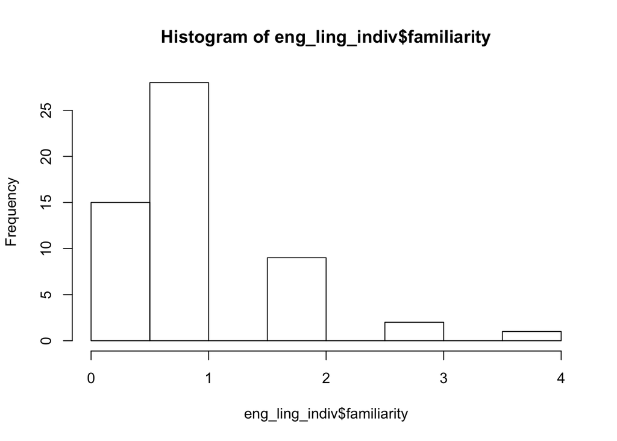

```r
eng_ling_indiv = subset(eng_indiv, Task = "Linguistic")
hist(eng_ling_indiv$familiarity)
```

```r
m1 = lm(accuracy~familiarity,data=eng_indiv[eng_indiv$task=="Linguistic",])
summary(m1)
```

```
##
## Call:
## lm(formula = accuracy ~ familiarity, data = eng_indiv[eng_indiv$task ==
##     "Linguistic", ])
##
## Residuals:
##      Min       1Q   Median       3Q      Max
## -26.8323 -10.6974  -0.7649  10.2689  27.2351
##
## Coefficients:
##             Estimate Std. Error t value Pr(>|t|)
## (Intercept)   54.832      2.719  20.167   <2e-16 ***
## familiarity    1.933      2.037   0.949    0.347
## ---
## Signif. codes:  0 '***' 0.001 '**' 0.01 '*' 0.05 '.' 0.1 ' ' 1
##
## Residual standard error: 13.04 on 53 degrees of freedom
## Multiple R-squared:  0.0167, Adjusted R-squared:  -0.001852
## F-statistic: 0.9002 on 1 and 53 DF,  p-value: 0.347
```

#### plot the correlation between vocabulary and the SL accuracy in the English speakers.

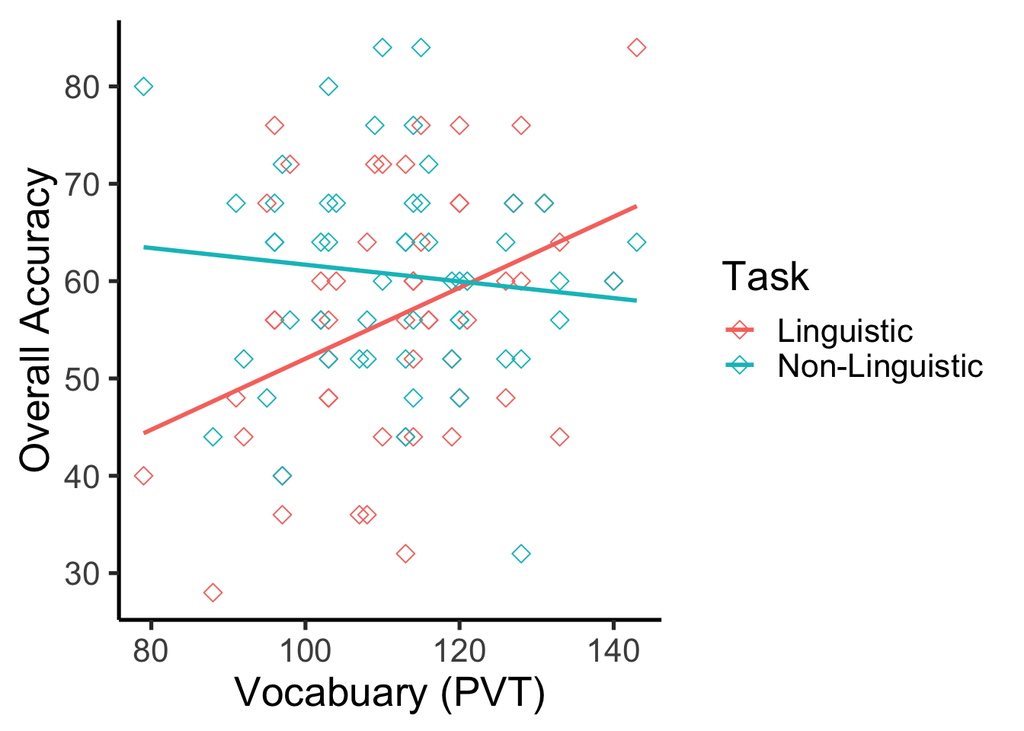

```r
colnames(eng_indiv)[8]="Task"
ggplot() +
  theme_classic(base_size = 20.0) +
  xlab(label = 'Vocabuary (PVT)') +
  ylab(label = 'Overall Accuracy') +
  scale_x_continuous(breaks = pretty_breaks()) +
  scale_y_continuous(breaks = pretty_breaks()) +
  geom_point(aes(x = vocabulary,y = accuracy,colour = Task),data=eng_indiv, shape = 23, size = 3) +
  geom_smooth(aes(x = vocabulary,y = accuracy,colour = Task),data=eng_indiv,method = lm,formula = 'y ~ x',se = FALSE)
```

```r
eng_ling_trial=subset(eng_trial,task=="1")
eng_ling_trial$fam_ratings=as.factor(as.character(eng_ling_trial$fam_ratings))
contrasts(eng_ling_trial$fam_ratings)=centerfactor(eng_ling_trial$fam_ratings)
m1 = glmer(trial_accuracy~fam_ratings+(1|subject),family = binomial,data=eng_ling_trial)
summary(m1)
```

```
## Generalized linear mixed model fit by maximum likelihood (Laplace
##   Approximation) [glmerMod]
##  Family: binomial  ( logit )
## Formula: trial_accuracy ~ fam_ratings + (1 | subject)
##    Data: eng_ling_trial
##
##      AIC      BIC   logLik deviance df.resid
##   1816.9   1853.3   -901.5   1802.9     1318
##
## Scaled residuals:
##     Min      1Q  Median      3Q     Max
## -1.5494 -1.0841  0.7393  0.8587  1.1741
##
## Random effects:
##  Groups  Name        Variance Std.Dev.
##  subject (Intercept) 0.1197   0.3459
## Number of obs: 1325, groups:  subject, 53
##
## Fixed effects:
##              Estimate Std. Error z value Pr(>|z|)
## (Intercept)   0.26775    0.07372   3.632 0.000281 ***
## fam_ratings1  0.09489    0.13044   0.727 0.466964
## fam_ratings2  0.05275    0.14111   0.374 0.708505
## fam_ratings3 -0.13570    0.21910  -0.619 0.535672
## fam_ratings4  0.30031    0.35800   0.839 0.401558
## fam_ratings5  0.49234    0.47909   1.028 0.304108
## ---
## Signif. codes:  0 '***' 0.001 '**' 0.01 '*' 0.05 '.' 0.1 ' ' 1
##
## Correlation of Fixed Effects:
##             (Intr) fm_rt1 fm_rt2 fm_rt3 fm_rt4
## fam_ratngs1  0.004
## fam_ratngs2  0.004  0.107
## fam_ratngs3 -0.002  0.136  0.255
## fam_ratngs4  0.008 -0.038 -0.061 -0.077
## fam_ratngs5  0.008  0.129  0.243  0.311  0.383
```

```r
hebindiv_asl<-hebindiv[which(hebindiv$group=="English"),]
hebindiv_ling_eng<- hebindiv_asl[which(hebindiv_asl$task == "Linguistic"),]

cor.test(hebindiv_ling_eng$accuracy,hebindiv_ling_eng$Q1, method = "spearman")
```

```
##
##  Spearman's rank correlation rho
##
## data:  hebindiv_ling_eng$accuracy and hebindiv_ling_eng$Q1
## S = 21053, p-value = 0.2798
## alternative hypothesis: true rho is not equal to 0
## sample estimates:
##       rho
## 0.1512132
```

```r
cor.test(hebindiv_ling_eng$accuracy,hebindiv_ling_eng$Q2, method = "spearman")
```

```
##
##  Spearman's rank correlation rho
##
## data:  hebindiv_ling_eng$accuracy and hebindiv_ling_eng$Q2
## S = 22041, p-value = 0.4271
## alternative hypothesis: true rho is not equal to 0
## sample estimates:
##       rho
## 0.1114087
```

```r
cor.test(hebindiv_ling_eng$accuracy,hebindiv_ling_eng$Q3, method = "spearman")
```

```
##
##  Spearman's rank correlation rho
##
## data:  hebindiv_ling_eng$accuracy and hebindiv_ling_eng$Q3
## S = 24704, p-value = 0.9771
## alternative hypothesis: true rho is not equal to 0
## sample estimates:
##         rho
## 0.004042225
```

```r
cor.test(hebindiv_ling_eng$accuracy,hebindiv_ling_eng$Q4, method = "spearman")
```

```
##
##  Spearman's rank correlation rho
##
## data:  hebindiv_ling_eng$accuracy and hebindiv_ling_eng$Q4
## S = 20994, p-value = 0.2722
## alternative hypothesis: true rho is not equal to 0
## sample estimates:
##      rho
## 0.153603
```

```r
cor.test(hebindiv_ling_eng$accuracy,hebindiv_ling_eng$Q5, method = "spearman")
```

```
##
##  Spearman's rank correlation rho
##
## data:  hebindiv_ling_eng$accuracy and hebindiv_ling_eng$Q5
## S = 20777, p-value = 0.2455
## alternative hypothesis: true rho is not equal to 0
## sample estimates:
##      rho
## 0.162336
```

### descriptive stats of the familiarity ranking

```r
library(likert)
library(psych)
library(ordinal)
# remove NA's
hebrank=subset(hebindiv_ling_eng,subject!="a_050")
hebrank=subset(hebrank,subject!="a_002")
hebrank=subset(hebrank,subject!="a_035")
hebrank=hebrank[c(11:15)]
hebrank$Q1 = factor(hebrank$Q1,
                       levels = c("0", "1", "2", "3", "4", "5"),
                       ordered = TRUE)
hebrank$Q2 = factor(hebrank$Q2,
                       levels = c("0", "1", "2", "3", "4", "5"),
                       ordered = TRUE)
hebrank$Q3 = factor(hebrank$Q3,
                       levels = c("0", "1", "2", "3", "4", "5"),
                       ordered = TRUE)
hebrank$Q4 = factor(hebrank$Q4,
                       levels = c("0", "1", "2", "3", "4", "5"),
                       ordered = TRUE)
hebrank$Q5 = factor(hebrank$Q5,
                       levels = c("0", "1", "2", "3", "4", "5"),
                       ordered = TRUE)
headTail(hebrank)
```

```
##       Q1   Q2   Q3   Q4   Q5
## 1      1    1    1    1    1
## 3      2    1    2    1    1
## 4      1    1    1    2    0
## 6      1    1    2    5    2
## ... <NA> <NA> <NA> <NA> <NA>
## 55     2    1    0    2    1
## 56     2    2    2    3    2
## 57     1    0    2    1    2
## 58     0    0    0    1    1
```

```r
summary(hebrank)
```

```
##  Q1     Q2     Q3     Q4     Q5
##  0:11   0:14   0:19   0: 9   0:17
##  1:24   1:23   1:19   1:22   1:19
##  2:15   2:11   2:12   2: 5   2:11
##  3: 1   3: 3   3: 1   3: 6   3: 1
##  4: 2   4: 2   4: 2   4: 7   4: 4
##  5: 0   5: 0   5: 0   5: 4   5: 1
```

```r
results=likert(hebrank)
summary(results)
```

```
##   Item      low neutral      high     mean        sd
## 4   Q4 67.92453       0 32.075472 2.849057 1.5615109
## 5   Q5 88.67925       0 11.320755 2.226415 1.2502540
## 2   Q2 90.56604       0  9.433962 2.169811 1.0140522
## 1   Q1 94.33962       0  5.660377 2.226415 0.9331813
## 3   Q3 94.33962       0  5.660377 2.018868 1.0093899
```

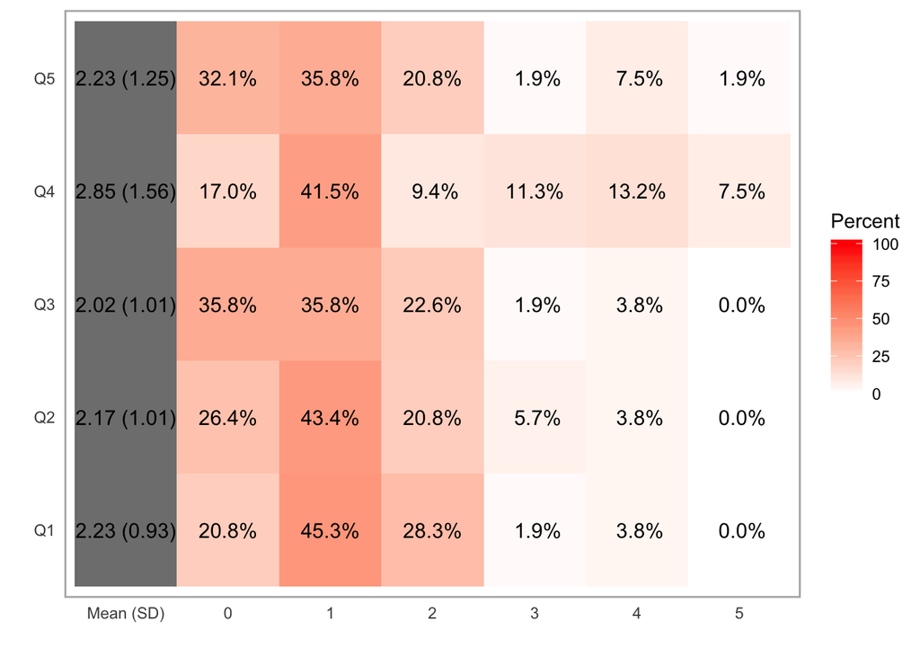

```r
plot(results,
     type="heat",
           low.color = "white",
           high.color = "red",
           text.color = "black",
           text.size = 4,
           wrap = 50)
```

```r
library(dunn.test)
hebrank=subset(hebindiv_ling_eng,subject!="a_050")
hebrank=subset(hebrank,subject!="a_002")
hebrank=subset(hebrank,subject!="a_035")
hebrank=hebrank[c(1,11:15)]
hebrank=melt(hebrank,id=1)
colnames(hebrank)[2]="item"
colnames(hebrank)[3]="ranking"
kruskal.test(ranking ~ item,
             data = hebrank)
```

```
##
##  Kruskal-Wallis rank sum test
##
## data:  ranking by item
## Kruskal-Wallis chi-squared = 8.6792, df = 4, p-value = 0.06964
```

```r
DT = dunn.test(hebrank$ranking,hebrank$item, method="bh")      # Adjusts p-values for multiple comparisons;
```

```
##   Kruskal-Wallis rank sum test
##
## data: x and group
## Kruskal-Wallis chi-squared = 8.6792, df = 4, p-value = 0.07
##
##
##                            Comparison of x by group
##                              (Benjamini-Hochberg)
## Col Mean-|
## Row Mean |         Q1         Q2         Q3         Q4
## ---------+--------------------------------------------
##       Q2 |   0.479725
##          |     0.3508
##       Q3 |   1.263521   0.783795
##          |     0.2064     0.3610
##       Q4 |  -1.511035  -1.990760  -2.774556
##          |     0.1635     0.0775     0.0276
##       Q5 |   0.609470   0.129745  -0.654050   2.120506
##          |     0.3389     0.4484     0.3665     0.0849
##
## alpha = 0.05
## Reject Ho if p <= alpha/2
```

### Testing the relationship between vocabulary and performance across tasks in the English group.

```r
glmvoc = glm(accuracy~vocabulary*Task,data=eng_indiv)
summary(glmvoc)
```

```
##
## Call:
## glm(formula = accuracy ~ vocabulary * Task, data = eng_indiv)
##
## Deviance Residuals:
##      Min        1Q    Median        3Q       Max
## -27.2827   -7.4114   -0.0117    6.6375   25.4301
##
## Coefficients:
##                               Estimate Std. Error t value Pr(>|t|)
## (Intercept)                    15.5589    13.3056   1.169  0.24499
## vocabulary                      0.3647     0.1183   3.084  0.00263 **
## TaskNon-Linguistic             54.7018    18.8170   2.907  0.00448 **
## vocabulary:TaskNon-Linguistic  -0.4505     0.1672  -2.694  0.00827 **
## ---
## Signif. codes:  0 '***' 0.001 '**' 0.01 '*' 0.05 '.' 0.1 ' ' 1
##
## (Dispersion parameter for gaussian family taken to be 132.6948)
##
##     Null deviance: 15374  on 105  degrees of freedom
## Residual deviance: 13535  on 102  degrees of freedom
##   (4 observations deleted due to missingness)
## AIC: 824.87
##
## Number of Fisher Scoring iterations: 2
```

### Testing the group by task interaction in a multi-level model based on the trial-by-trial data

```r
hebgroup.lmer <- glmer(trial_accuracy ~ 1 + language * task + (1|subject), family = binomial,control=glmerControl(optimizer="bobyqa", optCtrl=list(maxfun=2e5)), data = hebtrial)
summary(hebgroup.lmer)
```

```
## Generalized linear mixed model fit by maximum likelihood (Laplace
##   Approximation) [glmerMod]
##  Family: binomial  ( logit )
## Formula: trial_accuracy ~ 1 + language * task + (1 | subject)
##    Data: hebtrial
## Control:
## glmerControl(optimizer = "bobyqa", optCtrl = list(maxfun = 2e+05))
##
##      AIC      BIC   logLik deviance df.resid
##   6743.2   6776.1  -3366.6   6733.2     5295
##
## Scaled residuals:
##     Min      1Q  Median      3Q     Max
## -2.0939 -1.1600  0.6053  0.7609  1.1610
##
## Random effects:
##  Groups  Name        Variance Std.Dev.
##  subject (Intercept) 0.1233   0.3512
## Number of obs: 5300, groups:  subject, 106
##
## Fixed effects:
##                      Estimate Std. Error z value Pr(>|z|)
## (Intercept)           0.47405    0.07478   6.339 2.31e-10 ***
## languagehebrew        0.42561    0.10803   3.940 8.16e-05 ***
## task1                -0.20787    0.08004  -2.597   0.0094 **
## languagehebrew:task1  0.24169    0.11792   2.050   0.0404 *
## ---
## Signif. codes:  0 '***' 0.001 '**' 0.01 '*' 0.05 '.' 0.1 ' ' 1
##
## Correlation of Fixed Effects:
##             (Intr) lngghb task1
## languaghbrw -0.691
## task1       -0.545  0.377
## lngghbrw:t1  0.370 -0.548 -0.679
```

### Testing the correlation between linguistic and non-linguistic tasks for English Speakers

```r
hebindiv_eng<-hebindiv[which(hebindiv$group=="English"),]
hebindiv_ling_eng<- hebindiv_eng[which(hebindiv_eng$task == "Linguistic"),]
hebindiv_nonling_eng<- hebindiv_eng[which(hebindiv_eng$task == "Non-Linguistic"),]
cor.test(hebindiv_ling_eng$accuracy,hebindiv_nonling_eng$accuracy, method = "pearson")
```

```
##
##  Pearson's product-moment correlation
##
## data:  hebindiv_ling_eng$accuracy and hebindiv_nonling_eng$accuracy
## t = 1.3779, df = 53, p-value = 0.174
## alternative hypothesis: true correlation is not equal to 0
## 95 percent confidence interval:
##  -0.08344845  0.43004610
## sample estimates:
##       cor
## 0.1859658
```

### Testing the correlation between linguistic and non-linguistic tasks for Hebrew Speakers

```r
hebindiv_heb<-hebindiv[which(hebindiv$group=="Hebrew"),]
hebindiv_ling_heb<- hebindiv_heb[which(hebindiv_heb$task == "Linguistic"),]
hebindiv_nonling_heb<- hebindiv_heb[which(hebindiv_heb$task == "Non-Linguistic"),]
cor.test(hebindiv_ling_heb$accuracy,hebindiv_nonling_heb$accuracy, method = "pearson")
```

```
##
##  Pearson's product-moment correlation
##
## data:  hebindiv_ling_heb$accuracy and hebindiv_nonling_heb$accuracy
## t = 0.7809, df = 51, p-value = 0.4385
## alternative hypothesis: true correlation is not equal to 0
## 95 percent confidence interval:
##  -0.1664855  0.3681763
## sample estimates:
##       cor
## 0.1086998
```

### plot the bar graphs to illustrate interaction between two groups and two tasks

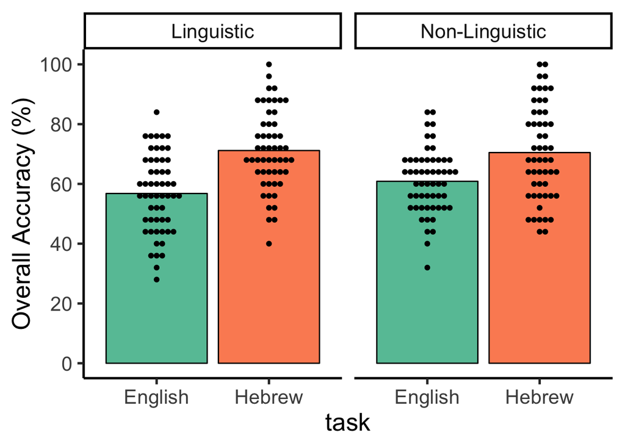

```r
ggplot() +
  theme_classic(base_size = 20.0) +
  ylab(label = 'Overall Accuracy (%)') +
  scale_y_continuous(breaks = pretty_breaks()) +
  geom_bar(aes(y = accuracy, x = group,fill = as.factor(group)),data=hebindiv,colour="black",fun.data = mean_sdl,stat = 'summary') +
  geom_beeswarm(aes(x = group,y = accuracy),data=hebindiv,dodge.width=0.9,cex=2.5) +
  facet_wrap(facets = ~task) +
  scale_x_discrete(name = 'task')+
  scale_fill_brewer(palette = 'Set2') +
  theme(legend.position = "none")
```

### plot the line graphs to illustrate interaction between two groups and two tasks

```r
d <- hebindiv %>%
       select(task, group, accuracy) %>%  # select relevant variables
       mutate(task = factor(task, labels = c("Linguistic", "Non-linguistic")),
              group = factor(group))

head(d)
```

```
##         task   group accuracy
## 1 Linguistic English       56
## 2 Linguistic English       44
## 3 Linguistic English       76
## 4 Linguistic English       60
## 5 Linguistic English       64
## 6 Linguistic English       76
```

```r
d %>%
  group_by(task, group) %>%
  summarise(accuracy_mean = mean(accuracy))
```

```
## # A tibble: 4 x 3
## # Groups:   task [?]
##   task           group   accuracy_mean
##   <fct>          <fct>           <dbl>
## 1 Linguistic     English          56.8
## 2 Linguistic     Hebrew           71.2
## 3 Non-linguistic English          60.9
## 4 Non-linguistic Hebrew           70.5
```

```r
sum_d <- d %>%
          group_by(task, group) %>%
          summarise(accuracy_mean = mean(accuracy),
                    se   = sd(accuracy)/sqrt(n()))
sum_d
```

```
## # A tibble: 4 x 4
## # Groups:   task [?]
##   task           group   accuracy_mean    se
##   <fct>          <fct>           <dbl> <dbl>
## 1 Linguistic     English          56.8  1.76
## 2 Linguistic     Hebrew           71.2  1.81
## 3 Non-linguistic English          60.9  1.44
## 4 Non-linguistic Hebrew           70.5  2.17
```

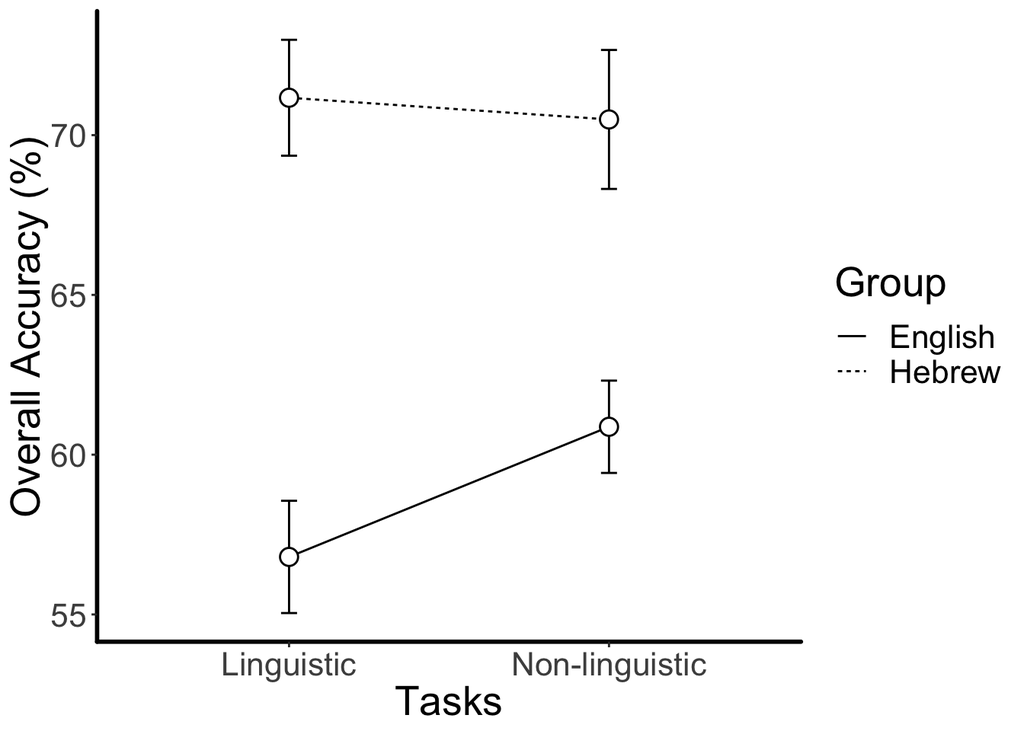

```r
pd <- position_dodge(width = 0)
sum_d %>%
  ggplot(aes(x = task, y = accuracy_mean, group = group)) +
    geom_line(aes(linetype = group), position = pd) +
    geom_errorbar(aes(ymin = accuracy_mean - se, ymax = accuracy_mean + se),
                  width = .1, position = pd) +
    geom_point(size = 4, position = pd) +
    geom_point(size = 3, color = "white", position = pd) +
    guides(linetype = guide_legend("Group")) +
    labs(x = "Tasks",
         y = "Overall Accuracy (%)") +
  theme(
    text=element_text(size=20),
    panel.background = element_rect(fill = "white"),         # Set plot background to white
    legend.key  = element_rect(fill = "white"),              # Set legend item backgrounds to white
    axis.line.x = element_line(colour = "black", size = 1),  # Add line to x axis
    axis.line.y = element_line(colour = "black", size = 1)   # Add line to y axis
  )
```